# Impact of contextual factors on deviations between eye-level and body-worn dosimeter measurements - Data preparation

Author

Sietse de Vries

## Summary

This file describes the preparation of light-dosimetry data for a statistical analysis. The statistical analysis aims to determine whether contextual factors significantly affect the differences between light measurements at eye-level and on the body (chest and wrist).

Personal light exposure measurements were collected at multiple sites as part of the MeLiDos project, following the protocol described by Guidolin et al. (Guidolin et al. 2024). The dataset of each site is available on GitHub:

- BAUA, Dortmund, Germany (Broszio, Zauner, and Spitschan 2025)
- FUSPCEU, Madrid, Spain (Baeza Moyano et al. 2025)
- IZTECH, Izmir, Turkey (Didikoglu et al. 2025)
- KNUST, Kumasi, Ghana (Akuffo et al. 2025)
- RISE, Borås, Sweden (Nilsson Tengelin et al. 2026)
- THUAS, the Hague, the Netherlands (Aerts et al. 2025)
- TUM, Munich, Germany (Hilden et al. 2025)
- UCR, San Pedro, San José, Costa Rica (Sancho-Salas et al. 2026)

```r
library(scales)
library(patchwork)
library(gt)         # used to make tables
library(tidyverse)
library(moments)
library(here)       # used to import and export the dataset(s)
```

## Load data

The datasets have been previously imported and filtered (see *SWV_data_import.qmd* for details).

```r
load(here("processed_data", "BAUA.RData"))
load(here("processed_data", "FUSPCEU.RData"))
load(here("processed_data", "IZTECH.RData"))
load(here("processed_data", "KNUST.RData"))
load(here("processed_data", "THUAS.RData"))
load(here("processed_data", "RISE.RData"))
load(here("processed_data", "TUM.RData"))
load(here("processed_data", "UCR.RData"))

# All datasets are set to the same time zone before combining. Values reflect local time and are kept as is.
BAUA$Datetime <- as.POSIXct(format(BAUA$Datetime, "%Y-%m-%d %H:%M:%S"), tz = "UTC")
FUSPCEU$Datetime <- as.POSIXct(format(FUSPCEU$Datetime, "%Y-%m-%d %H:%M:%S"), tz = "UTC")
IZTECH$Datetime <- as.POSIXct(format(IZTECH$Datetime, "%Y-%m-%d %H:%M:%S"), tz = "UTC")
KNUST$Datetime <- as.POSIXct(format(KNUST$Datetime, "%Y-%m-%d %H:%M:%S"), tz = "UTC")
RISE$Datetime <- as.POSIXct(format(RISE$Datetime, "%Y-%m-%d %H:%M:%S"), tz = "UTC")
THUAS$Datetime <- as.POSIXct(format(THUAS$Datetime, "%Y-%m-%d %H:%M:%S"), tz = "UTC")
TUM$Datetime <- as.POSIXct(format(TUM$Datetime, "%Y-%m-%d %H:%M:%S"), tz = "UTC")
UCR$Datetime <- as.POSIXct(format(UCR$Datetime, "%Y-%m-%d %H:%M:%S"), tz = "UTC")

# Combine datasets
ALL_hcw <- dplyr::bind_rows(BAUA, FUSPCEU, IZTECH, KNUST, THUAS, TUM, UCR)
```

## Format activity data

```r
act_cat <- c(
  "act_sleep", "act_home", "act_road_vehicle", "act_road_open",
  "act_working_indoor", "act_working_outdoor", "act_free_outdoor", "act_other")

total_n <- nrow(ALL_hcw |> ungroup())

ALL_hcw |>
  ungroup() |>
  count(across(all_of(act_cat)), name = "n") |>
  mutate(
    perc = round(n / total_n * 100, 2),
    flag = case_when(
      if_all(all_of(act_cat), ~ . == FALSE) ~ "all FALSE",
      if_all(all_of(act_cat), is.na) ~ "all NA",
      TRUE ~ ""
    )
  ) |>
  arrange(desc(n)) |>
  gt() |>
  tab_style(
    style = cell_fill(color = "orange"),
    locations = cells_body(rows = flag %in% c("all FALSE", "all NA"))
  ) |>
  tab_style(
    style = cell_fill(color = "lightgreen"),
    locations = map(act_cat, ~ cells_body(
      columns = all_of(.x),
      rows = !!sym(.x) == TRUE
    ))
  ) |>
  cols_hide(columns = flag) |>
  tab_options(table.font.size = px(10))
```

Table 1: Distribution of activity category combinations

| act_sleep | act_home | act_road_vehicle | act_road_open | act_working_indoor | act_working_outdoor | act_free_outdoor | act_other | n | perc |
| --- | --- | --- | --- | --- | --- | --- | --- | --- | --- |
| FALSE | TRUE | FALSE | FALSE | FALSE | FALSE | FALSE | FALSE | 1090390 | 34.88 |
| FALSE | FALSE | FALSE | FALSE | TRUE | FALSE | FALSE | FALSE | 994192 | 31.80 |
| NA | NA | NA | NA | NA | NA | NA | NA | 193208 | 6.18 |
| FALSE | FALSE | TRUE | FALSE | FALSE | FALSE | FALSE | FALSE | 156278 | 5.00 |
| FALSE | FALSE | FALSE | FALSE | FALSE | FALSE | TRUE | FALSE | 144517 | 4.62 |
| TRUE | FALSE | FALSE | FALSE | FALSE | FALSE | FALSE | FALSE | 108913 | 3.48 |
| FALSE | FALSE | FALSE | FALSE | FALSE | FALSE | FALSE | TRUE | 104527 | 3.34 |
| FALSE | FALSE | FALSE | TRUE | FALSE | FALSE | FALSE | FALSE | 93872 | 3.00 |
| FALSE | FALSE | FALSE | FALSE | FALSE | TRUE | FALSE | FALSE | 41070 | 1.31 |
| FALSE | TRUE | FALSE | FALSE | TRUE | FALSE | FALSE | FALSE | 26195 | 0.84 |
| FALSE | FALSE | TRUE | TRUE | FALSE | FALSE | FALSE | FALSE | 17800 | 0.57 |
| FALSE | TRUE | TRUE | FALSE | FALSE | FALSE | FALSE | FALSE | 17587 | 0.56 |
| FALSE | FALSE | FALSE | TRUE | TRUE | FALSE | FALSE | FALSE | 17221 | 0.55 |
| FALSE | FALSE | TRUE | FALSE | TRUE | FALSE | FALSE | FALSE | 16780 | 0.54 |
| FALSE | TRUE | FALSE | TRUE | FALSE | FALSE | FALSE | FALSE | 13866 | 0.44 |
| FALSE | FALSE | FALSE | FALSE | FALSE | FALSE | FALSE | FALSE | 12049 | 0.39 |
| FALSE | TRUE | FALSE | FALSE | FALSE | FALSE | TRUE | FALSE | 11652 | 0.37 |
| TRUE | TRUE | FALSE | FALSE | FALSE | FALSE | FALSE | FALSE | 8096 | 0.26 |
| FALSE | FALSE | FALSE | TRUE | FALSE | FALSE | TRUE | FALSE | 7581 | 0.24 |
| FALSE | FALSE | FALSE | TRUE | FALSE | FALSE | FALSE | TRUE | 6869 | 0.22 |
| FALSE | FALSE | TRUE | FALSE | FALSE | FALSE | TRUE | FALSE | 6745 | 0.22 |
| FALSE | FALSE | FALSE | FALSE | TRUE | FALSE | TRUE | FALSE | 6728 | 0.22 |
| FALSE | FALSE | FALSE | FALSE | TRUE | TRUE | FALSE | FALSE | 6685 | 0.21 |
| FALSE | FALSE | TRUE | FALSE | FALSE | FALSE | FALSE | TRUE | 5863 | 0.19 |
| FALSE | FALSE | TRUE | TRUE | TRUE | FALSE | FALSE | FALSE | 2387 | 0.08 |
| FALSE | FALSE | FALSE | FALSE | FALSE | FALSE | TRUE | TRUE | 1804 | 0.06 |
| FALSE | FALSE | FALSE | TRUE | FALSE | TRUE | FALSE | FALSE | 1776 | 0.06 |
| FALSE | TRUE | TRUE | TRUE | FALSE | FALSE | FALSE | FALSE | 1731 | 0.06 |
| FALSE | FALSE | FALSE | FALSE | TRUE | FALSE | FALSE | TRUE | 1371 | 0.04 |
| FALSE | TRUE | FALSE | FALSE | FALSE | FALSE | FALSE | TRUE | 1123 | 0.04 |
| FALSE | FALSE | TRUE | TRUE | FALSE | FALSE | FALSE | TRUE | 866 | 0.03 |
| FALSE | FALSE | FALSE | TRUE | TRUE | FALSE | FALSE | TRUE | 722 | 0.02 |
| FALSE | FALSE | TRUE | FALSE | TRUE | FALSE | TRUE | FALSE | 722 | 0.02 |
| FALSE | FALSE | TRUE | TRUE | FALSE | FALSE | TRUE | FALSE | 722 | 0.02 |
| FALSE | TRUE | FALSE | TRUE | TRUE | FALSE | FALSE | FALSE | 722 | 0.02 |
| FALSE | TRUE | TRUE | FALSE | FALSE | FALSE | TRUE | FALSE | 722 | 0.02 |
| TRUE | FALSE | FALSE | TRUE | FALSE | FALSE | FALSE | FALSE | 720 | 0.02 |
| TRUE | FALSE | FALSE | FALSE | TRUE | FALSE | FALSE | FALSE | 691 | 0.02 |
| FALSE | TRUE | TRUE | FALSE | TRUE | FALSE | FALSE | FALSE | 451 | 0.01 |
| FALSE | TRUE | FALSE | FALSE | FALSE | TRUE | FALSE | FALSE | 361 | 0.01 |
| FALSE | TRUE | TRUE | TRUE | FALSE | FALSE | FALSE | TRUE | 361 | 0.01 |
| TRUE | FALSE | FALSE | FALSE | FALSE | FALSE | FALSE | TRUE | 180 | 0.01 |
| TRUE | FALSE | TRUE | FALSE | FALSE | FALSE | FALSE | FALSE | 144 | 0.00 |

The distribution of the combinations of activities (noted hourly by the participants during the measurements) are shown in Table 1. Note, while measurements taken during sleep were excluded in previous filtering, some may still be categorized as act_sleep due to the hourly time resolution of the contextual data.

To decrease the number of combinations, the data is formatted (`act_context` column) into general categories deemed representative of the various activity contexts:

- `home` (*act_home*)
- `working_indoor` (*act_working_indoor*)
- `road_vehicle` (*act_road_vehicle*)
- `outdoor_act` (*act_free_outdoor* or *act_road_open* or *act_working_outdoor* or *act_road_open* and *act_working_outdoor* or *act_road_open* and *act_free_outdoor*)
- `other_act` (Any other category or combination. Also includes rows with only *FALSE* or *NA*)

```r
ALL_hcw <- ALL_hcw |>
  ungroup() |>
  mutate(
    act_context = case_when(
      act_home == TRUE &
        act_sleep == FALSE & act_road_vehicle == FALSE & act_road_open == FALSE &
        act_working_indoor == FALSE & act_working_outdoor == FALSE &
        act_free_outdoor == FALSE & act_other == FALSE ~ "home",
      act_working_indoor == TRUE &
        act_sleep == FALSE & act_home == FALSE & act_road_vehicle == FALSE &
        act_road_open == FALSE & act_working_outdoor == FALSE &
        act_free_outdoor == FALSE & act_other == FALSE ~ "working_indoor",
      act_road_vehicle == TRUE &
        act_sleep == FALSE & act_home == FALSE & act_road_open == FALSE &
        act_working_indoor == FALSE & act_working_outdoor == FALSE &
        act_free_outdoor == FALSE & act_other == FALSE ~ "road_vehicle",
      (act_free_outdoor == TRUE &
        act_sleep == FALSE & act_home == FALSE & act_road_vehicle == FALSE &
        act_road_open == FALSE & act_working_indoor == FALSE &
        act_working_outdoor == FALSE & act_other == FALSE) |
      (act_free_outdoor == FALSE &
        act_sleep == FALSE & act_home == FALSE & act_road_vehicle == FALSE &
        act_road_open == TRUE & act_working_indoor == FALSE &
        act_working_outdoor == FALSE & act_other == FALSE) |
      (act_free_outdoor == FALSE &
        act_sleep == FALSE & act_home == FALSE & act_road_vehicle == FALSE &
        act_road_open == FALSE & act_working_indoor == FALSE &
        act_working_outdoor == TRUE & act_other == FALSE) |
      (act_free_outdoor == FALSE &
        act_sleep == FALSE & act_home == FALSE & act_road_vehicle == FALSE &
        act_road_open == TRUE & act_working_indoor == FALSE &
        act_working_outdoor == TRUE & act_other == FALSE) |
      (act_free_outdoor == TRUE &
        act_sleep == FALSE & act_home == FALSE & act_road_vehicle == FALSE &
        act_road_open == TRUE & act_working_indoor == FALSE &
        act_working_outdoor == FALSE & act_other == FALSE) ~ "outdoor_act",
      TRUE ~ "other_act"
      ),
    act_context = factor(act_context, levels = c(
      "home",
      "working_indoor",
      "road_vehicle",
      "outdoor_act",
      "other_act"
    ))
  )
```

## Format environment (indoor/outdoor)

Additionally, the activity data is formatted (`environment` column) to indicate whether the participant was indoors or outdoors:

- `indoor` (*act_home* or *act_working_indoor* or *act_sleep* or *act_home* and *act_working_indoor* or *act_home* and *act_sleep*)
- `outdoor` (*act_road_vehicle* or *act_free_outdoor* or *act_road_open* or *act_working_outdoor* or *act_road_vehicle* and *act_road_open* or *act_free_outdoor* and *act_road_open* or *act_free_outdoor* and *act_road_vehicle* or *act_road_open* and *act_working_outdoor*)
- `other_env` (Any other category or combination. Also includes rows with only *FALSE* or *NA*)

Note, although act_road_vehicle may strictly be considered an indoor environment, it is classified as outdoor because of the extensive glazing typically present.

```r
ALL_hcw <- ALL_hcw |>
  ungroup() |>
  mutate(
    environment = case_when(
            (act_free_outdoor == FALSE &
        act_sleep == FALSE & act_home == TRUE & act_road_vehicle == FALSE &
        act_road_open == FALSE & act_working_indoor == FALSE &
        act_working_outdoor == FALSE & act_other == FALSE) |
      (act_free_outdoor == FALSE &
        act_sleep == FALSE & act_home == FALSE & act_road_vehicle == FALSE &
        act_road_open == FALSE & act_working_indoor == TRUE &
        act_working_outdoor == FALSE & act_other == FALSE) |
      (act_free_outdoor == FALSE &
        act_sleep == TRUE & act_home == FALSE & act_road_vehicle == FALSE &
        act_road_open == FALSE & act_working_indoor == FALSE &
        act_working_outdoor == FALSE & act_other == FALSE) |
      (act_free_outdoor == FALSE &
        act_sleep == FALSE & act_home == TRUE & act_road_vehicle == FALSE &
        act_road_open == FALSE & act_working_indoor == TRUE &
        act_working_outdoor == FALSE & act_other == FALSE) |
      (act_free_outdoor == FALSE &
        act_sleep == TRUE & act_home == TRUE & act_road_vehicle == FALSE &
        act_road_open == FALSE & act_working_indoor == FALSE &
        act_working_outdoor == FALSE & act_other == FALSE) ~ "indoor",
      (act_free_outdoor == FALSE &
        act_sleep == FALSE & act_home == FALSE & act_road_vehicle == TRUE &
        act_road_open == FALSE & act_working_indoor == FALSE &
        act_working_outdoor == FALSE & act_other == FALSE) |
      (act_free_outdoor == TRUE &
        act_sleep == FALSE & act_home == FALSE & act_road_vehicle == FALSE &
        act_road_open == FALSE & act_working_indoor == FALSE &
        act_working_outdoor == FALSE & act_other == FALSE) |
      (act_free_outdoor == FALSE &
        act_sleep == FALSE & act_home == FALSE & act_road_vehicle == FALSE &
        act_road_open == TRUE & act_working_indoor == FALSE &
        act_working_outdoor == FALSE & act_other == FALSE) |
      (act_free_outdoor == FALSE &
        act_sleep == FALSE & act_home == FALSE & act_road_vehicle == FALSE &
        act_road_open == FALSE & act_working_indoor == FALSE &
        act_working_outdoor == TRUE & act_other == FALSE) |
      (act_free_outdoor == FALSE &
        act_sleep == FALSE & act_home == FALSE & act_road_vehicle == TRUE &
        act_road_open == TRUE & act_working_indoor == FALSE &
        act_working_outdoor == FALSE & act_other == FALSE) |
      (act_free_outdoor == TRUE &
        act_sleep == FALSE & act_home == FALSE & act_road_vehicle == FALSE &
        act_road_open == TRUE & act_working_indoor == FALSE &
        act_working_outdoor == FALSE & act_other == FALSE) |
      (act_free_outdoor == TRUE &
        act_sleep == FALSE & act_home == FALSE & act_road_vehicle == TRUE &
        act_road_open == FALSE & act_working_indoor == FALSE &
        act_working_outdoor == FALSE & act_other == FALSE) |
      (act_free_outdoor == FALSE &
        act_sleep == FALSE & act_home == FALSE & act_road_vehicle == FALSE &
        act_road_open == TRUE & act_working_indoor == FALSE &
        act_working_outdoor == TRUE & act_other == FALSE) ~ "outdoor",
      TRUE ~ "other_env"
    ),
    environment = factor(environment, levels = c(
      "outdoor",
      "indoor",
      "other_env"
    ))
  ) |>
  select(-starts_with("act_"), act_context) # Remove activity booleans
```

## Average to hours

As the contextual data was recorded at an hourly resolution, all light measurements are aggregated to hourly means. This prevents pseudo-replication, where repeated 10-second measurements within the same hour would otherwise appear as independent observations despite sharing identical contextual labels.

As photoperiod state may change within an hour, the state with the highest occurrence within the hour is used.

```r
ALL_hcw_hourly <- ALL_hcw |>
  group_by(Id, timeofday, day, site, lightsource_primary, lightsource_secondary, environment, act_context) |>
  summarise(
    MEDI_h = mean(MEDI_h, na.rm = TRUE),
    MEDI_c = mean(MEDI_c, na.rm = TRUE),
    MEDI_w = mean(MEDI_w, na.rm = TRUE),
    absdif_c = mean(absdif_c, na.rm = TRUE),
    absdif_w = mean(absdif_w, na.rm = TRUE),
    logdif_c = mean(logdif_c, na.rm = TRUE),
    logdif_w = mean(logdif_w, na.rm = TRUE),
    photoperiod.state = names(which.max(table(photoperiod.state))),
    .groups = "drop"
  ) |>
  mutate(photoperiod.state = as.factor(photoperiod.state))
```

## Filter participants

The distribution of participants is shown in Figure 1. As participants BAUA_S007, BAUA_S008, and BAUA_S011 have less than one day of observations, they are excluded.

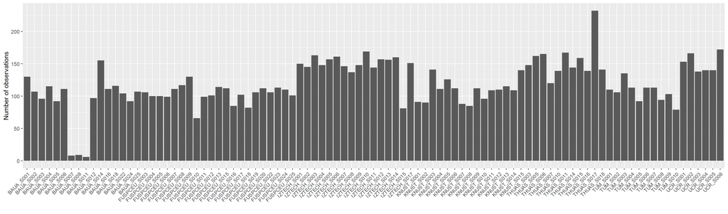

Figure 1: Distribution of observations per participant.

```r
ALL_hcw_hourly |>
  ungroup() |>
  count(Id, name = "n") |>
  ggplot(aes(x = Id, y = n)) +
  geom_col() +
  labs(x = "", y = "Number of observations") +
  theme(axis.text.x = element_text(angle = 45, hjust = 1))

# Remove participants with less than one day of observations
ALL_hcw_hourly <- ALL_hcw_hourly |>
  filter(!Id %in% c("BAUA_S007", "BAUA_S008", "BAUA_S011"))
```

## Data overview

The distributions of the differences between (hourly mean) log-transformed eye-level and body-worn dosimeters measurements (`logdif_c` and `logdif_w`)) during daytime, nighttime, indoor, and outdoor conditions are given in Figure 2 to Figure 5. *Note: When I made these figures, I wasn’t aware of the symlog function, so the data is binned manually.*

```r
make_hcw_plot <- function(data, filter_expr) {

  ALL_hcw <- data |>
    filter({{ filter_expr }}) |>
    select(Id, MEDI_h, MEDI_c, MEDI_w)

  # Non-zero / zero splits
  ALL_hc <- ALL_hcw |> filter(MEDI_h != 0, MEDI_c != 0) |> mutate(across(c(MEDI_h, MEDI_c), log10))
  ALL_hw <- ALL_hcw |> filter(MEDI_h != 0, MEDI_w != 0) |> mutate(across(c(MEDI_h, MEDI_w), log10))
  ALL_h0_c <- ALL_hcw |> filter(MEDI_h == 0, MEDI_c != 0) |> mutate(MEDI_c = log10(MEDI_c)) |> select(MEDI_c)
  ALL_h0_w <- ALL_hcw |> filter(MEDI_h == 0, MEDI_w != 0) |> mutate(MEDI_w = log10(MEDI_w)) |> select(MEDI_w)
  ALL_h_c0 <- ALL_hcw |> filter(MEDI_c == 0, MEDI_h != 0) |> mutate(MEDI_h = log10(MEDI_h)) |> select(MEDI_h)
  ALL_h_w0 <- ALL_hcw |> filter(MEDI_w == 0, MEDI_h != 0) |> mutate(MEDI_h = log10(MEDI_h)) |> select(MEDI_h)
  ALL_h0_c0 <- ALL_hcw |> filter(MEDI_h == 0, MEDI_c == 0)
  ALL_h0_w0 <- ALL_hcw |> filter(MEDI_h == 0, MEDI_w == 0)

  # Binning
  binwidth <- 0.2

  bin_2d <- function(df, v1, v2) {
    df |> ungroup() |>
      mutate(
        "{v1}_bin" := floor(.data[[v1]] / binwidth) * binwidth,
        "{v2}_bin" := floor(.data[[v2]] / binwidth) * binwidth
      )
  }

  bin_1d <- function(df, v) {
    df |> ungroup() |>
      mutate("{v}_bin" := floor(.data[[v]] / binwidth) * binwidth)
  }

  ALL_hc_bins <- bin_2d(ALL_hc, "MEDI_h", "MEDI_c")
  ALL_hw_bins <- bin_2d(ALL_hw, "MEDI_h", "MEDI_w")
  ALL_h0_c_bins <- bin_1d(ALL_h0_c, "MEDI_c")
  ALL_h0_w_bins <- bin_1d(ALL_h0_w, "MEDI_w")
  ALL_h_c0_bins <- bin_1d(ALL_h_c0, "MEDI_h")
  ALL_h_w0_bins <- bin_1d(ALL_h_w0, "MEDI_h")

  # Counts
  clamp_low <- function(df, ...) {
    vars <- rlang::ensyms(...)
    df |>
      mutate(across(c(!!!vars), \(x) ifelse(x < 0, -0.2, x))) |>
      group_by(across(c(!!!vars))) |>
      summarise(n = sum(n), .groups = "drop")
  }

  ALL_hc_bins_counts <- ALL_hc_bins  |> count(MEDI_h_bin, MEDI_c_bin, name = "n") |> clamp_low(MEDI_h_bin, MEDI_c_bin)
  ALL_hw_bins_counts <- ALL_hw_bins  |> count(MEDI_h_bin, MEDI_w_bin, name = "n") |> clamp_low(MEDI_h_bin, MEDI_w_bin)
  ALL_h0_c_bins_counts <- ALL_h0_c_bins |> count(MEDI_c_bin, name = "n") |> clamp_low(MEDI_c_bin)
  ALL_h0_w_bins_counts <- ALL_h0_w_bins |> count(MEDI_w_bin, name = "n") |> clamp_low(MEDI_w_bin)
  ALL_h_c0_bins_counts <- ALL_h_c0_bins |> count(MEDI_h_bin, name = "n") |> clamp_low(MEDI_h_bin)
  ALL_h_w0_bins_counts <- ALL_h_w0_bins |> count(MEDI_h_bin, name = "n") |> clamp_low(MEDI_h_bin)
  ALL_h0_c0_count <- ALL_h0_c0 |> ungroup() |> count(MEDI_h, name = "n")
  ALL_h0_w0_count <- ALL_h0_w0 |> ungroup() |> count(MEDI_h, name = "n")

  # Shared fill scale
  global_min <- min(ALL_hc_bins_counts$n, ALL_hw_bins_counts$n,
                    ALL_h0_c_bins_counts$n, ALL_h0_w_bins_counts$n,
                    ALL_h_c0_bins_counts$n, ALL_h_w0_bins_counts$n,
                    ALL_h0_c0_count$n, ALL_h0_w0_count$n)
  global_max <- max(ALL_hc_bins_counts$n, ALL_hw_bins_counts$n,
                    ALL_h0_c_bins_counts$n, ALL_h0_w_bins_counts$n,
                    ALL_h_c0_bins_counts$n, ALL_h_w0_bins_counts$n,
                    ALL_h0_c0_count$n, ALL_h0_w0_count$n)
  log_breaks <- 10^seq(floor(log10(5)), ceiling(log10(global_max)), by = 1)

  fill_scale <- scale_fill_viridis_c(
    trans = "log10", option = "plasma", name = "Count",
    limits = c(global_min, global_max),
    breaks = log_breaks, labels = scales::label_number()
  )

  # Layout design
  design <- c(
    area(t = 1, l = 1, b = 1, r = 1),
    area(t = 1, l = 2, b = 1, r = 2),
    area(t = 2, l = 1, b = 2, r = 1),
    area(t = 2, l = 2, b = 2, r = 2)
  )

  # Plot builder helpers
  tick_segments <- function(positions, axis, direction, offset = 0.2) {
    # axis: "x" or "y", direction: "in" or "out"
    if (axis == "x") {
      y_base <- if (direction == "out") 0 else positions[length(positions)] + offset
      y_tip  <- if (direction == "out") -offset else positions[length(positions)]
      df <- data.frame(x = positions, xend = positions,
                       y = if (direction == "out") 0 else 5.2,
                       yend = if (direction == "out") -offset else 5)
    } else {
      df <- data.frame(y = positions, yend = positions,
                       x = if (direction == "out") 0 else 5.2,
                       xend = if (direction == "out") -offset else 5)
    }
    geom_segment(data = df, aes(x = x, xend = xend, y = y, yend = yend),
                 inherit.aes = FALSE, linewidth = 0.6)
  }

  make_main_plot <- function(counts, x_bin, y_bin) {
    ggplot() +
      geom_rect(data = counts,
                aes(xmin = .data[[x_bin]], xmax = .data[[x_bin]] + binwidth,
                    ymin = .data[[y_bin]], ymax = .data[[y_bin]] + binwidth,
                    fill = n)) +
      coord_fixed() +
      scale_x_continuous(limits = c(-0.2, 5.2), expand = c(0,0),
                         breaks = seq(0, 5), labels = NULL) +
      scale_y_continuous(limits = c(-0.2, 5.2), expand = c(0,0),
                         breaks = seq(0, 5), labels = NULL) +
      fill_scale +
      geom_abline(slope = 1, intercept = 0, color = "black",
                  linetype = "dashed", linewidth = 0.8) +
      theme_minimal() +
      theme(panel.border = element_rect(colour = "black", fill = NA, linewidth = 1)) +
      # tick marks
      geom_segment(data = data.frame(x=seq(0,5), xend=seq(0,5), y=0, yend=-0.2),
                   aes(x=x,xend=xend,y=y,yend=yend), inherit.aes=FALSE, linewidth=0.6) +
      geom_segment(data = data.frame(y=seq(0,5), yend=seq(0,5), x=0, xend=-0.2),
                   aes(x=x,xend=xend,y=y,yend=yend), inherit.aes=FALSE, linewidth=0.6) +
      geom_segment(data = data.frame(x=seq(0,5), xend=seq(0,5), y=5.2, yend=5),
                   aes(x=x,xend=xend,y=y,yend=yend), inherit.aes=FALSE, linewidth=0.6) +
      geom_segment(data = data.frame(y=seq(0,5), yend=seq(0,5), x=5.2, xend=5),
                   aes(x=x,xend=xend,y=y,yend=yend), inherit.aes=FALSE, linewidth=0.6) +
      labs(x = NULL, y = NULL, fill = "Count")
  }

  make_h0_plot <- function(counts, x_bin, x_lab) {
    ggplot() +
      geom_rect(data = counts,
                aes(xmin = .data[[x_bin]], xmax = .data[[x_bin]] + binwidth,
                    ymin = 0, ymax = binwidth, fill = n)) +
      coord_fixed() +
      scale_x_continuous(limits = c(-0.2, 5.2), expand = c(0,0),
                         breaks = seq(0, 5),
                         labels = function(x) scales::label_number(accuracy=1)(10^x)) +
      scale_y_continuous(limits = c(0, binwidth), expand = c(0,0),
                         breaks = binwidth/2, labels = NULL) +
      fill_scale + guides(fill = "none") +
      labs(x = x_lab, y = NULL) +
      theme_minimal() +
      theme(panel.border = element_rect(colour = "black", fill = NA, linewidth = 1),
            panel.grid = element_blank()) +
      geom_segment(data = data.frame(x=seq(0,5), xend=seq(0,5), y=0, yend=0.2),
                   aes(x=x,xend=xend,y=y,yend=yend), inherit.aes=FALSE,
                   linewidth=0.6, color="black")
  }

  make_c0_plot <- function(counts, y_lab) {
    ggplot() +
      geom_rect(data = counts,
                aes(xmin = 0, xmax = binwidth,
                    ymin = MEDI_h_bin, ymax = MEDI_h_bin + binwidth, fill = n)) +
      coord_fixed() +
      scale_x_continuous(limits = c(0, binwidth), expand = c(0,0),
                         breaks = binwidth/2, labels = NULL) +
      scale_y_continuous(limits = c(-0.2, 5.2), expand = c(0,0),
                         breaks = seq(0, 5),
                         labels = function(x) scales::label_number(accuracy=1)(10^x)) +
      fill_scale + guides(fill = "none") +
      labs(x = NULL, y = y_lab) +
      theme_minimal() +
      theme(panel.border = element_rect(colour = "black", fill = NA, linewidth = 1),
            panel.grid = element_blank()) +
      geom_segment(data = data.frame(x=0, xend=0.2, y=seq(0,5), yend=seq(0,5)),
                   aes(x=x,xend=xend,y=y,yend=yend), inherit.aes=FALSE,
                   linewidth=0.6, color="black")
  }

  make_h0c0_plot <- function(counts) {
    ggplot() +
      geom_rect(data = counts,
                aes(xmin=0, xmax=binwidth, ymin=0, ymax=binwidth, fill=n)) +
      coord_fixed() +
      scale_x_continuous(limits=c(0,binwidth), expand=c(0,0), breaks=binwidth/2, labels=0) +
      scale_y_continuous(limits=c(0,binwidth), expand=c(0,0), breaks=binwidth/2, labels=0) +
      fill_scale + guides(fill = "none") +
      theme_minimal() +
      theme(panel.border = element_rect(colour="black", fill=NA, linewidth=1),
            panel.grid = element_blank())
  }

  # Assemble the two composite plots
  plot_headvschest <- (
    make_c0_plot(ALL_h_c0_bins_counts, "Eye-level dosimeter [m-EDI lx]") +
    make_main_plot(ALL_hc_bins_counts, "MEDI_c_bin", "MEDI_h_bin") +
    make_h0c0_plot(ALL_h0_c0_count) +
    make_h0_plot(ALL_h0_c_bins_counts, "MEDI_c_bin", "Chest-worn dosimeter [m-EDI lx]")
  ) + plot_layout(design = design)

  plot_headvswrist <- (
    make_c0_plot(ALL_h_w0_bins_counts, NULL) +
    make_main_plot(ALL_hw_bins_counts, "MEDI_w_bin", "MEDI_h_bin") +
    make_h0c0_plot(ALL_h0_w0_count) +
    make_h0_plot(ALL_h0_w_bins_counts, "MEDI_w_bin", "Wrist-worn dosimeter [m-EDI lx]")
  ) + plot_layout(design = design)

  (plot_headvschest | plot_headvswrist) +
    plot_layout(guides = "collect")
  }
```

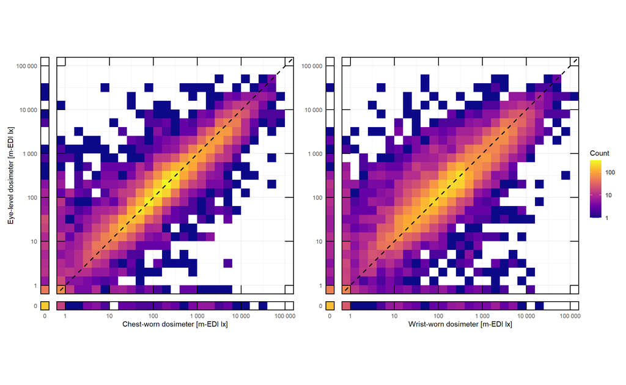

Figure 2: Distribution of head-worn and chest/wrist-worn dosimeter measurements during daytime (photoperiod.state = day).

```r
make_hcw_plot(ALL_hcw_hourly, photoperiod.state == "day")
```

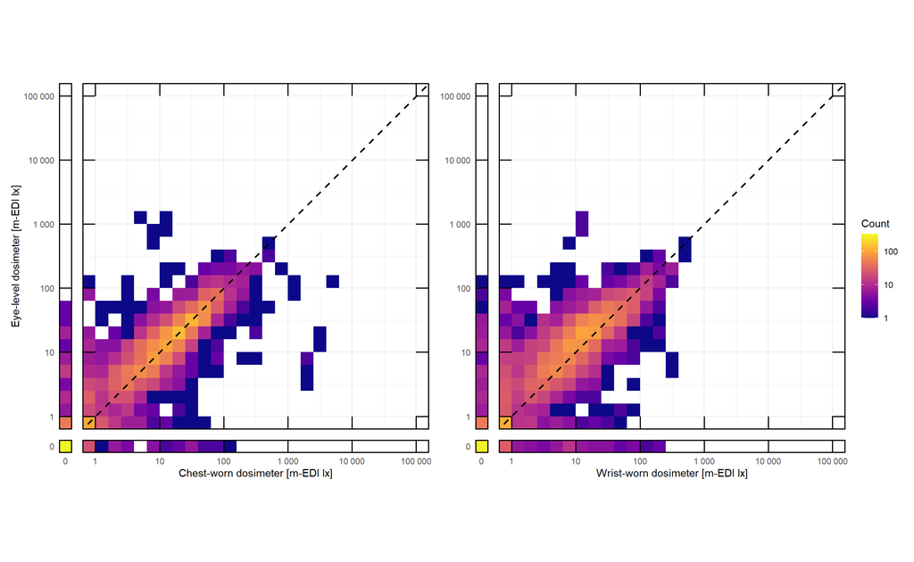

Figure 3: Distribution of head-worn and chest/wrist-worn dosimeter measurements during nighttime (photoperiod.state = night).

```r
make_hcw_plot(ALL_hcw_hourly, photoperiod.state == "night")
```

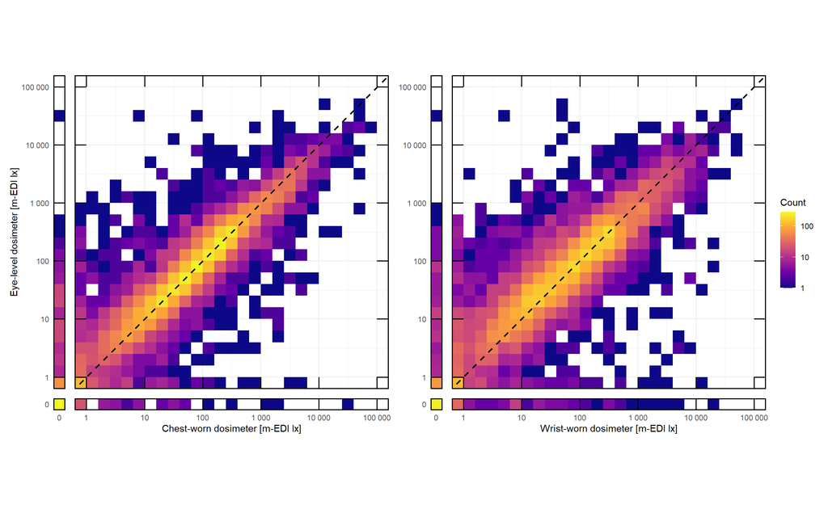

Figure 4: Distribution of head-worn and chest/wrist-worn dosimeter measurements in indoor environments (environment = indoor).

```r
make_hcw_plot(ALL_hcw_hourly, environment == "indoor")
```

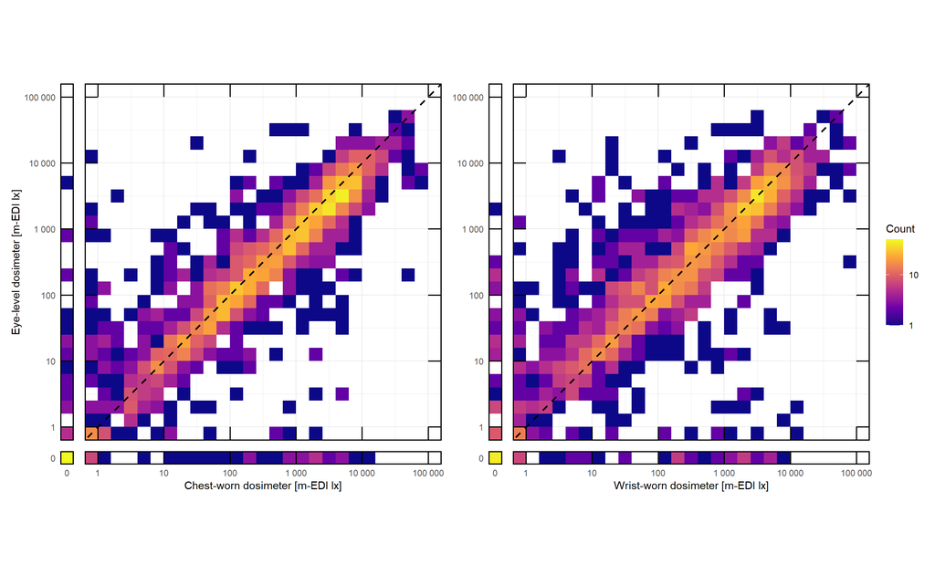

Figure 5: Distribution of head-worn and chest/wrist-worn dosimeter measurements in outdoor environments (environment = outdoor).

```r
make_hcw_plot(ALL_hcw_hourly, environment == "outdoor")
```

The distributions of the differences between head-worn and chest-worn (`absdif_c` and `logdif_c`) and wrist-worn (`absdif_w` and `logdif_w`) dosimeter measurements are shown in Figure 6.

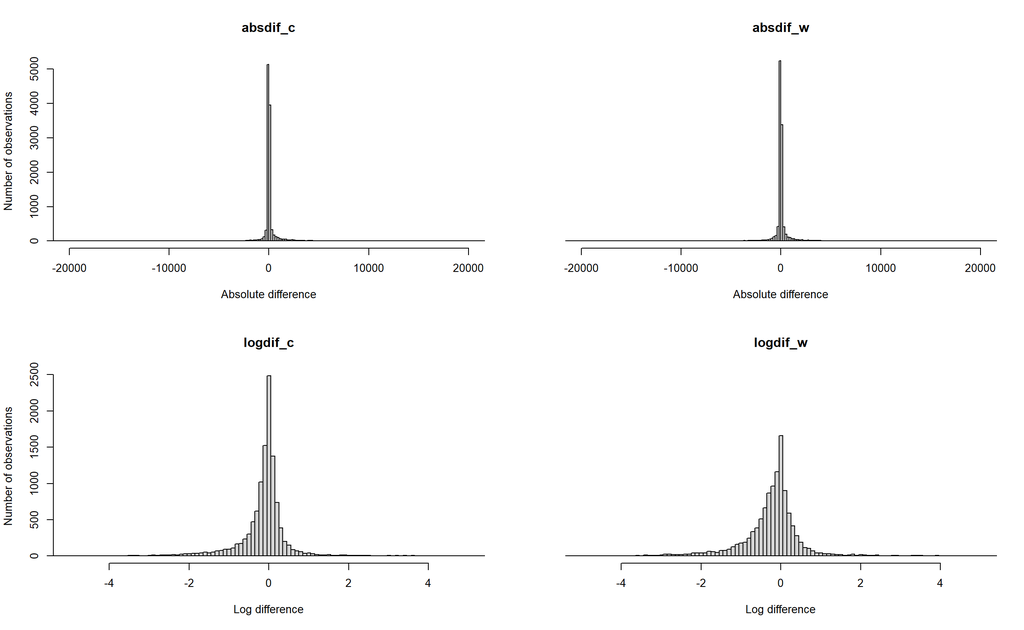

Figure 6: Distribution of differences between head-worn and chest/wrist-worn dosimeter measurements.

```r
par(mfrow = c(2, 2))

# Row 1: absdif plots
abs_range <- ceiling(max(abs(c(ALL_hcw_hourly$absdif_c, ALL_hcw_hourly$absdif_w)), na.rm = TRUE) / 200) * 200
breaks_abs <- seq(-abs_range, abs_range, by = 200)

ylim_abs <- range(0, hist(ALL_hcw_hourly$absdif_c, plot = FALSE, breaks = breaks_abs)$counts,
                      hist(ALL_hcw_hourly$absdif_w, plot = FALSE, breaks = breaks_abs)$counts)
hist(ALL_hcw_hourly$absdif_c, breaks = breaks_abs,
     xlab = "Absolute difference", ylab = "Number of observations", main = "absdif_c",
     ylim = ylim_abs, xlim = c(-20000, 20000))
hist(ALL_hcw_hourly$absdif_w, breaks = breaks_abs,
     xlab = "Absolute difference", main = "absdif_w", ylim = ylim_abs, xlim = c(-20000, 20000),
     yaxt = "n", ylab = "")


# Row 2: logdif plots
ylim_log <- range(0, hist(ALL_hcw_hourly$logdif_c, plot = FALSE, breaks = seq(-6.05, 6.05, by = 0.1))$counts,
                      hist(ALL_hcw_hourly$logdif_w, plot = FALSE, breaks = seq(-6.05, 6.05, by = 0.1))$counts)
hist(ALL_hcw_hourly$logdif_c, breaks = seq(-6.05, 6.05, by = 0.1),
     xlab = "Log difference", ylab = "Number of observations", main = "logdif_c", ylim = ylim_log, xlim = c(-5, 5))
hist(ALL_hcw_hourly$logdif_w, breaks = seq(-6.05, 6.05, by = 0.1),
     xlab = "Log difference", main = "logdif_w", ylim = ylim_log, xlim = c(-5, 5),
     yaxt = "n", ylab = "")

par(mfrow = c(1, 1))
```

Both logdif distributions are leptokurtic — meaning they have a sharp, narrow peak and heavy tails — as confirmed by kurtosis values substantially exceeding 3:

```r
kurtosis(ALL_hcw_hourly$logdif_c)
```

```
[1] 14.38266
```

```r
kurtosis(ALL_hcw_hourly$logdif_w)
```

```
[1] 9.651101
```

```r
# Observation per environment
ALL_hcw_hourly |>
  ungroup() |>
  count(environment, name = "n_observations") |>
  mutate(perc_observations = paste0(round(n_observations / sum(n_observations) * 100, 2), "%")) |>
  left_join(
    ALL_hcw |>
      ungroup() |>
      distinct(environment, Id) |>
      count(environment, name = "n_participants"),
    by = "environment"
  ) |>
  gt()
```

| environment | n_observations | perc_observations | n_participants |
| --- | --- | --- | --- |
| outdoor | 1749 | 15.48% | 90 |
| indoor | 7923 | 70.14% | 93 |
| other_env | 1624 | 14.38% | 90 |

```r
# Observations per activity
ALL_hcw_hourly |>
  ungroup() |>
  count(act_context, name = "n_observations") |>
  mutate(perc_observations = paste0(round(n_observations / sum(n_observations) * 100, 2), "%")) |>
  left_join(
    ALL_hcw |>
      ungroup() |>
      distinct(act_context, Id) |>
      count(act_context, name = "n_participants"),
    by = "act_context"
  ) |>
  gt()
```

| act_context | n_observations | perc_observations | n_participants |
| --- | --- | --- | --- |
| home | 3929 | 34.78% | 92 |
| working_indoor | 3304 | 29.25% | 90 |
| road_vehicle | 592 | 5.24% | 81 |
| outdoor_act | 1051 | 9.3% | 80 |
| other_act | 2420 | 21.42% | 94 |

```r
# Observations per primary light source
ALL_hcw_hourly |>
  ungroup() |>
  count(lightsource_primary, name = "n_observations") |>
  mutate(perc_observations = paste0(round(n_observations / sum(n_observations) * 100, 2), "%")) |>
  left_join(
    ALL_hcw |>
      ungroup() |>
      distinct(lightsource_primary, Id) |>
      count(lightsource_primary, name = "n_participants"),
    by = "lightsource_primary"
  ) |>
  gt()
```

| lightsource_primary | n_observations | perc_observations | n_participants |
| --- | --- | --- | --- |
| Electric light source indoors | 4178 | 36.99% | 93 |
| Electric light source outdoors | 231 | 2.04% | 45 |
| Daylight indoors | 3735 | 33.06% | 93 |
| Daylight outdoors (including shade) | 1436 | 12.71% | 88 |
| Emissive display light | 599 | 5.3% | 59 |
| Darkness during sleep | 409 | 3.62% | 75 |
| Light entering from outside during sleep | 72 | 0.64% | 23 |
| NA | 636 | 5.63% | 78 |

```r
# Observations per secondary light source
ALL_hcw_hourly |>
  ungroup() |>
  count(lightsource_secondary, name = "n_observations") |>
  mutate(perc_observations = paste0(round(n_observations / sum(n_observations) * 100, 2), "%")) |>
  left_join(
    ALL_hcw |>
      ungroup() |>
      distinct(lightsource_secondary, Id) |>
      count(lightsource_secondary, name = "n_participants"),
    by = "lightsource_secondary"
  ) |>
  gt()
```

| lightsource_secondary | n_observations | perc_observations | n_participants |
| --- | --- | --- | --- |
| Electric light source indoors | 767 | 6.79% | 58 |
| Electric light source outdoors | 103 | 0.91% | 24 |
| Daylight indoors | 1030 | 9.12% | 72 |
| Daylight outdoors (including shade) | 392 | 3.47% | 48 |
| Emissive display light | 3259 | 28.85% | 79 |
| Darkness during sleep | 56 | 0.5% | 25 |
| Light entering from outside during sleep | 83 | 0.73% | 27 |
| NA | 5606 | 49.63% | 95 |

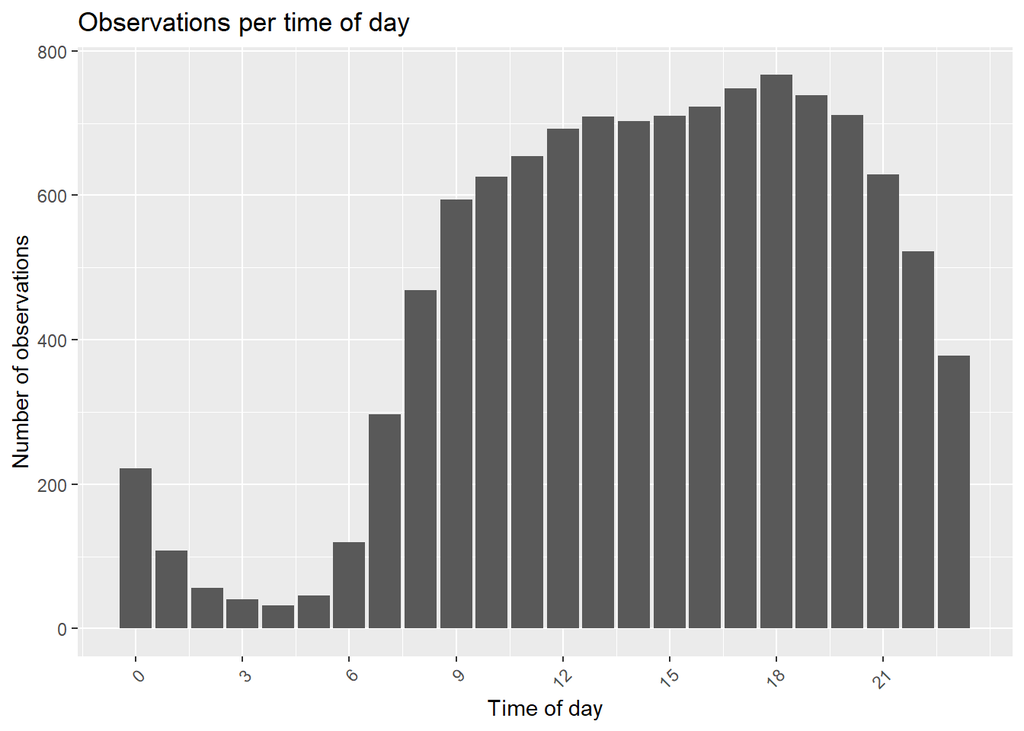

```r
# Observations per timeofday
ALL_hcw_hourly |>
  ungroup() |>
  count(timeofday, name = "n") |>
  mutate(timeofday = as.numeric(as.character(timeofday))) |>  # or just as.numeric() if already numeric-ish
  ggplot(aes(x = timeofday, y = n)) +
  geom_col() +
  scale_x_continuous(breaks = seq(0, 23, by = 3)) +
  labs(x = "Time of day", y = "Number of observations", title = "Observations per time of day") +
  theme(axis.text.x = element_text(angle = 45, hjust = 1))
```

```r
# Observations per site
ALL_hcw_hourly |>
  ungroup() |>
  count(site, name = "n_observations") |>
  mutate(perc_observations = round(n_observations / sum(n_observations) * 100, 2)) |>
  left_join(
    ALL_hcw |>
      ungroup() |>
      distinct(site, Id) |>
      count(site, name = "n_participants"),
    by = "site"
  ) |>
  gt()
```

| site | n_observations | perc_observations | n_participants |
| --- | --- | --- | --- |
| BAUA | 1433 | 12.69 | 16 |
| FUSPCEU | 2172 | 19.23 | 21 |
| IZTECH | 2373 | 21.01 | 16 |
| KNUST | 1635 | 14.47 | 15 |
| THUAS | 1716 | 15.19 | 11 |
| TUM | 1058 | 9.37 | 10 |
| UCR | 909 | 8.05 | 6 |

```r
# Observations per photoperiod.state
ALL_hcw_hourly |>
  ungroup() |>
  count(photoperiod.state, name = "n_observations") |>
  mutate(perc_observations = round(n_observations / sum(n_observations) * 100, 2)) |>
  left_join(
    ALL_hcw |>
      ungroup() |>
      distinct(photoperiod.state, Id) |>
      count(photoperiod.state, name = "n_participants"),
    by = "photoperiod.state"
  ) |>
  gt()
```

| photoperiod.state | n_observations | perc_observations | n_participants |
| --- | --- | --- | --- |
| day | 8481 | 75.08 | 95 |
| night | 2815 | 24.92 | 91 |

An overview of the final data structure is given in Table 2.

```r
ALL_hcw_hourly |>
  ungroup() |>
  summarise(across(everything(), list(
    type    = ~ class(.)[1],
    example = ~ as.character(.[!is.na(.)][100])
  ))) |>
  pivot_longer(everything(),
               names_to  = c("variable", ".value"),
               names_sep = "_(?=[^_]+$)") |>
  mutate(example = ifelse(
    !is.na(suppressWarnings(as.numeric(example))),
    suppressWarnings(as.character(round(as.numeric(example), 2))),
    example
  )) |>
  gt()
```

Table 2: Overview of dataset

| variable | type | example |
| --- | --- | --- |
| Id | character | BAUA_S001 |
| timeofday | factor | 18 |
| day | factor | 2 |
| site | factor | BAUA |
| lightsource_primary | factor | Darkness during sleep |
| lightsource_secondary | factor | Emissive display light |
| environment | factor | indoor |
| act_context | factor | home |
| MEDI_h | numeric | 1489.39 |
| MEDI_c | numeric | 4310.07 |
| MEDI_w | numeric | 3677.89 |
| absdif_c | numeric | 2820.68 |
| absdif_w | numeric | 2188.5 |
| logdif_c | numeric | 0.12 |
| logdif_w | numeric | 0.13 |
| photoperiod.state | factor | day |

## Data export

All datasets are saved as one `.RData` file.

```r
output_dir <- here("processed_data")
save(ALL_hcw_hourly, file = here("processed_data", "ALL_hcw_proc.RData"))
```

## Acknowledgments

Code optimization was conducted using Claude Opus 4.6 (Anthropic). All generated suggestions were reviewed and validated by the author, who takes full responsibility for the final code and results.

## References

Aerts, Sam, Astrid Astrid Jansen, Nico Hogervorst, Daan Boesten, John Bolte, Johannes Zauner, and Manuel Spitschan. 2025. *Personal Light Exposure Dataset for Delft, the Netherlands*. Zenodo. https://doi.org/10.5281/ZENODO.17979893.

Akuffo, Kwadwo Owusu, Gabriel Kwaku Agbeshie, Johannes Zauner, and Manuel Spitschan. 2025. *Personal Light Exposure Dataset for Kumasi, Ghana*. Zenodo. https://doi.org/10.5281/ZENODO.15576731.

Baeza Moyano, David, María Concepción Pérez Gutiérrez, Guadalupe Cantarero García, Roberto Alonso González Lezcano, Sofía Melero Tur, Johannes Zauner, and Manuel Spitschan. 2025. *Personal Light Exposure Dataset for Madrid, Spain*. Zenodo. https://doi.org/10.5281/ZENODO.16834951.

Broszio, Kai, Johannes Zauner, and Manuel Spitschan. 2025. *Personal Light Exposure Dataset for Dortmund, Germany*. Zenodo. https://doi.org/10.5281/ZENODO.18111232.

Didikoglu, Altug, Sena Gulsum Akgun, Sema Nur Aydin, Zeynep Kayar, Johannes Zauner, and Manuel Spitschan. 2025. *Personal Light Exposure Dataset for Izmir, Türkiye*. Zenodo. https://doi.org/10.5281/ZENODO.16568109.

Guidolin, Carolina, Sam Aerts, Gabriel Kwaku Agbeshie, Kwadwo Owusu Akuffo, Sema Nur Aydin, David Baeza-Moyano, John Bolte, et al. 2024. “Protocol for a Prospective, Multicentre, Cross-Sectional Cohort Study to Assess Personal Light Exposure.” *BMC Public Health* 24 (1). https://doi.org/10.1186/s12889-024-20206-4.

Hilden, Sarina, Suyoun Lee, Johannes Zauner, and Manuel Spitschan. 2025. *Personal Light Exposure Dataset for Munich, Germany*. Zenodo. https://doi.org/10.5281/ZENODO.16893901.

Nilsson Tengelin, Maria, Ingemar Svensson, Stefan Källberg, Johannes Zauner, and Manuel Spitschan. 2026. *Personal Light Exposure Dataset for Borås, Sweden*. Zenodo. https://doi.org/10.5281/ZENODO.18925834.

Sancho-Salas, Andrea, Helga von-Breymann, Johannes Zauner, and Manuel Spitschan. 2026. *Personal Light Exposure Dataset for San Pedro, San José, Costa Rica*. Zenodo. https://doi.org/10.5281/ZENODO.17289456.